# Visualizing Causal Graphs with caugi

## Working with Different Graph Types

The plotting system works with all graph types supported by `caugi`.

### Partially Directed Acyclic Graphs (PDAGs)

First, let’s create a PDAG with both directed and undirected edges:

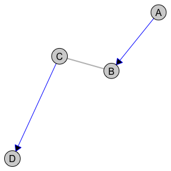

```r
pdag <- caugi(
  A %-->% B,
  B %---% C, # Undirected edge
  C %-->% D,
  class = "PDAG"
)

plot(
  pdag,
  edge_style = list(
    directed = list(col = "blue"),
    undirected = list(col = "gray", lwd = 2)
  )
)
```

### Acyclic Directed Mixed Graphs (ADMGs)

Here’s an example of an ADMG with directed and bidirected edges:

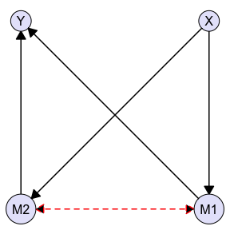

```r
complex_admg <- caugi(
  X %-->% M1 + M2,
  M1 %-->% Y,
  M2 %-->% Y,
  M1 %<->% M2, # Latent confounder between mediators
  class = "ADMG"
)

plot(
  complex_admg,
  layout = "kamada-kawai",
  node_style = list(fill = "lavender"),
  edge_style = list(
    directed = list(col = "black", lwd = 1.5),
    bidirected = list(col = "red", lwd = 1.5, lty = "dashed", arrow_size = 3)
  )
)
```

### Undirected Graphs (UGs)

We also support undirected graphs. Here’s a Markov random field example:

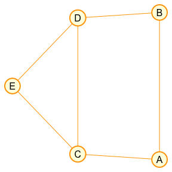

```r
markov <- caugi(
  A %---% B + C,
  B %---% D,
  C %---% D + E,
  D %---% E,
  class = "UG"
)

plot(
  markov,
  layout = "fruchterman-reingold",
  node_style = list(
    fill = "lightyellow",
    col = "orange",
    lwd = 2
  ),
  edge_style = list(col = "orange")
)
```

## Plot Composition

The `caugi` package provides intuitive operators for composing multiple plots into complex layouts, similar to the patchwork package.

### Basic Composition

Use `+` or `|` for horizontal arrangement and `/` for vertical stacking:

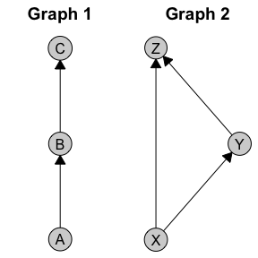

```r
# Create two different graphs
g1 <- caugi(
  A %-->% B,
  B %-->% C,
  class = "DAG"
)

g2 <- caugi(
  X %-->% Y,
  Y %-->% Z,
  X %-->% Z,
  class = "DAG"
)

# Create plots
p1 <- plot(g1, main = "Graph 1")
p2 <- plot(g2, main = "Graph 2")

# Horizontal composition (side-by-side)
p1 + p2
```

The `|` operator is an alias for `+`:

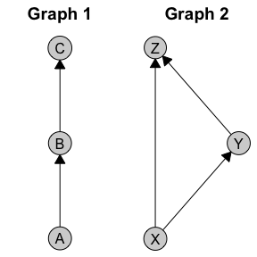

```r
# Equivalent to p1 + p2
p1 | p2
```

For vertical stacking, use the `/` operator:

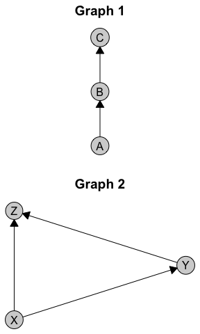

```r
p1 / p2
```

### Nested Compositions

Compositions can be nested to create complex multi-plot layouts:

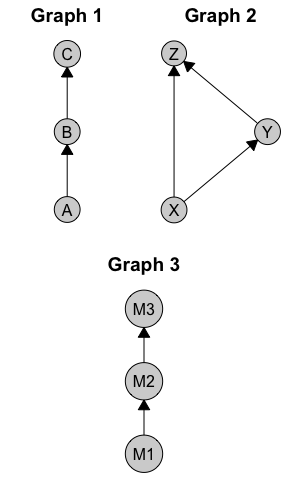

```r
g3 <- caugi(
  M1 %-->% M2,
  M2 %-->% M3,
  class = "DAG"
)

p3 <- plot(g3, main = "Graph 3")

# Complex layout: two plots on top, one below
(p1 + p2) / p3
```

You can mix operators freely. Here’s an example combining horizontal and vertical arrangements:

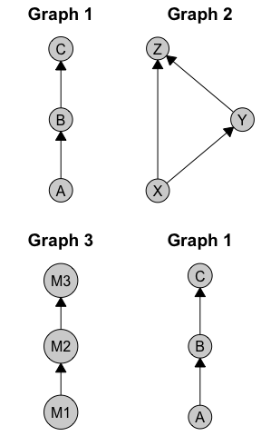

```r
(p1 + p2) / (p3 + p1)
```

### Configuring Spacing

The spacing between composed plots is controlled globally via `caugi_options()`:

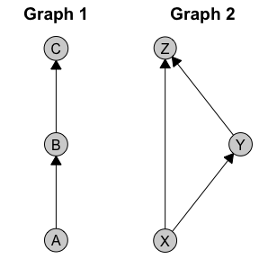

```r
caugi_options(plot = list(spacing = grid::unit(2, "lines")))

p1 + p2
```

To reset the default, you can call `caugi_default_options()`:

```r
caugi_options(caugi_default_options())
```

## Global Plot Options

The `caugi_options()` function allows you to set global defaults for plot appearance, which can be overridden on a per-plot basis.

### Setting Default Styles

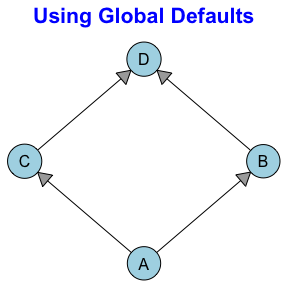

```r
# Configure global defaults
caugi_options(plot = list(
  node_style = list(fill = "lightblue", padding = 3),
  edge_style = list(arrow_size = 4, fill = "darkgray"),
  title_style = list(col = "blue", fontsize = 16)
))

# This plot uses the global defaults
plot(cg, main = "Using Global Defaults")
```

### Per-Plot Overrides

Global options serve as defaults that can be overridden:

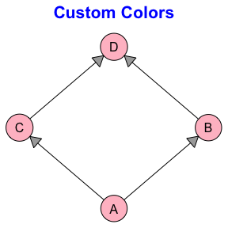

```r
# Set global node color
caugi_options(plot = list(
  node_style = list(fill = "lightblue")
))

# Override for this specific plot
plot(cg,
  main = "Custom Colors",
  node_style = list(fill = "pink")
)
```

```r
# Reset to defauls
caugi_options(caugi_default_options())
```

### Available Options

The following options can be configured under `plot`:

- **`spacing`**: A `grid::unit()` controlling space between composed plots
- **`node_style`**: List with `fill`, `padding`, and `size`
- **`edge_style`**: List with `arrow_size`, `circle_size`, `fill`, and `route`
- **`label_style`**: List of text parameters (see `grid::gpar()`)
- **`title_style`**: List with `col`, `fontface`, and `fontsize`

```r
# View all current options
caugi_options()
```

```
#> $use_open_graph_definition
#> [1] TRUE
#>
#> $plot
#> $plot$spacing
#> [1] 1lines
#>
#> $plot$node_style
#> $plot$node_style$fill
#> [1] "lightgrey"
#>
#> $plot$node_style$padding
#> [1] 2
#>
#> $plot$node_style$size
#> [1] 1
#>
#>
#> $plot$edge_style
#> $plot$edge_style$arrow_size
#> [1] 3
#>
#> $plot$edge_style$circle_size
#> [1] 1.5
#>
#> $plot$edge_style$fill
#> [1] "black"
#>
#> $plot$edge_style$route
#> [1] TRUE
#>
#>
#> $plot$label_style
#> list()
#>
#> $plot$title_style
#> $plot$title_style$col
#> [1] "black"
#>
#> $plot$title_style$fontface
```

[output cut: 15 more lines]

```
#>
#> $plot$tier_style$col
#> [1] "transparent"
#>
#> $plot$tier_style$label_style
#> list()
#>
#> $plot$tier_style$lwd
#> [1] 1
#>
#> $plot$tier_style$alpha
#> [1] 1
#>
#> $plot$tier_style$padding
#> [1] 4mm
```

```r
# Query specific option
caugi_options("plot")
```

```
#> $spacing
#> [1] 1lines
#>
#> $node_style
#> $node_style$fill
#> [1] "lightgrey"
#>
#> $node_style$padding
#> [1] 2
#>
#> $node_style$size
#> [1] 1
#>
#>
#> $edge_style
#> $edge_style$arrow_size
#> [1] 3
#>
#> $edge_style$circle_size
#> [1] 1.5
#>
#> $edge_style$fill
#> [1] "black"
#>
#> $edge_style$route
#> [1] TRUE
#>
#>
#> $label_style
#> list()
#>
#> $title_style
#> $title_style$col
#> [1] "black"
#>
#> $title_style$fontface
#> [1] "bold"
#>
#> $title_style$fontsize
#> [1] 14.4
```

[output cut: 11 more lines]

```
#>
#> $tier_style$col
#> [1] "transparent"
#>
#> $tier_style$label_style
#> list()
#>
#> $tier_style$lwd
#> [1] 1
#>
#> $tier_style$alpha
#> [1] 1
#>
#> $tier_style$padding
#> [1] 4mm
```

## Advanced Usage

### Manual Layouts

You can compute layouts separately and reuse them. First, compute the layout coordinates:

```r
coords <- caugi_layout(dag, method = "sugiyama")

# The layout can be used for analysis or custom plotting
print(coords)
```

```
#>   name    x   y
#> 1   X1 0.25 0.0
#> 2   X2 0.75 0.0
#> 3   M1 0.00 0.5
#> 4   M2 0.50 0.5
#> 5   M3 1.00 0.5
#> 6    Y 0.50 1.0
```

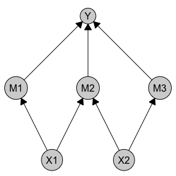

```r
# Plot uses the same layout, calling caugi_layout internally
plot(dag, layout = "sugiyama")
```

### Integration with Grid Graphics

`caugi` plots are built on grid graphics, and provide access to the underlying grid `grob` object in the `@grob` slot of the plot output. This allows for further customization using grid functions.

```r
# Create a plot
p <- plot(cg)

# The grob slot is a grid graphics object
class(p@grob)
```

```
#> [1] "gTree" "grob"  "gDesc"
```

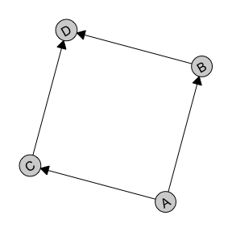

```r
# You can manipulate it with grid functions
library(grid)

# Draw the plot rotated by 30 degrees
pushViewport(viewport(angle = 30))
grid.draw(p@grob)
popViewport()
```

The composition operators work by manipulating these grid grobs, creating flexible and performant multi-plot layouts without requiring external packages.

## References

Fruchterman, Thomas M. J., and Edward M. Reingold. 1991. “Graph Drawing by Force-Directed Placement.” *Software: Practice and Experience* 21 (11): 1129–64. https://doi.org/10.1002/spe.4380211102.

Kamada, Tomihisa, and Satoru Kawai. 1989. “An Algorithm for Drawing General Undirected Graphs.” *Information Processing Letters* 31 (1): 7–15. https://doi.org/10.1016/0020-0190(89)90102-6.

Sugiyama, Kozo, Shojiro Tagawa, and Mitsuhiko Toda. 1981. “Methods for Visual Understanding of Hierarchical System Structures.” *IEEE Transactions on Systems, Man, and Cybernetics* 11 (2): 109–25. https://doi.org/10.1109/TSMC.1981.4308636.